# Basic K-means clustering in R

Dr Patrycja Delong-Smith

6 January 2022

# K-means clustering

This tutorial explains how to perform basic k-means clustering in R.

Clustering is a data science technique, which can be used to divide data into groups based on their similarity. K-means is one of the most popular unsupervised machine learning algorithms.

Let’s start with a simple example to try to understand how the algorithm works. We would like to identify 2 groups within 2-dimensional data sample.

## K-means algorithm

1. At first the alogorithm assigns data point to k-clusters (2 in our example) and compute inital centroids as mean for observations in each cluster.
2. Then it computes the distances between the centroids and every data point, which is assigned to the closest cluster.
3. Means (centroid locations) of the clusters are updated using data points assigned to them.
4. Steps 2 and 3 are repeated until centroids no longer change.

[video not shown]

## Advantages and disadvantages fo k-means

### Advantages:

- fast and scales well to large datasets
- simple to implement
- doesn’t require labels

### Diasdvantages:

- depends on the inital random cluster assignment
- requires user to specify the number of clusters
- only works well with clusters of similar sizes, but it can be adapted to account for this

# K-means in R

Load iris dataset containing and check its’ format.

```r
data("iris")
str(iris)
```

```
## 'data.frame':    150 obs. of  5 variables:
##  $ Sepal.Length: num  5.1 4.9 4.7 4.6 5 5.4 4.6 5 4.4 4.9 ...
##  $ Sepal.Width : num  3.5 3 3.2 3.1 3.6 3.9 3.4 3.4 2.9 3.1 ...
##  $ Petal.Length: num  1.4 1.4 1.3 1.5 1.4 1.7 1.4 1.5 1.4 1.5 ...
##  $ Petal.Width : num  0.2 0.2 0.2 0.2 0.2 0.4 0.3 0.2 0.2 0.1 ...
##  $ Species     : Factor w/ 3 levels "setosa","versicolor",..: 1 1 1 1 1 1 1 1 1 1 ...
```

For simplicity we’ll use just 2 variables. We should also normalize the dataset - we can do this using scale funtion. Then we can have a quick look at the data using plot funtion.

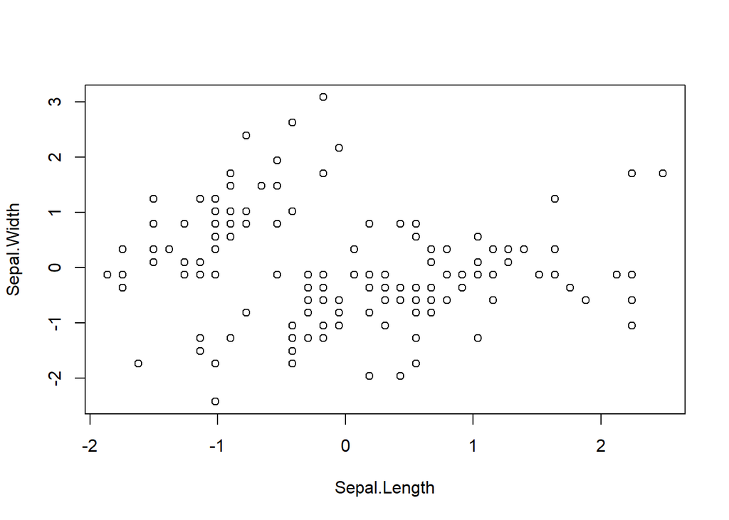

```r
# select first 2 columns
df = scale(iris[1:2])
plot(df)
```

We set numbers of clusters to 3 and nstart parameter to 5. Nstart defines the number of the random sets to initialise the algorithm. Default nstart is equal to 1, which can lead to unstable results.

Str function checks the structure of the output.

```r
k3 = kmeans(df, 3, nstart = 5)
str(k3)
```

```
## List of 9
##  $ cluster     : int [1:150] 2 2 2 2 2 2 2 2 2 2 ...
##  $ centers     : num [1:3, 1:2] -0.0588 -0.9987 1.1607 -0.9018 0.9032 ...
##   ..- attr(*, "dimnames")=List of 2
##   .. ..$ : chr [1:3] "1" "2" "3"
##   .. ..$ : chr [1:2] "Sepal.Length" "Sepal.Width"
##  $ totss       : num 298
##  $ withinss    : num [1:3] 34.3 38.7 28.9
##  $ tot.withinss: num 102
##  $ betweenss   : num 196
##  $ size        : int [1:3] 56 49 45
##  $ iter        : int 3
##  $ ifault      : int 0
##  - attr(*, "class")= chr "kmeans"
```

As you can see it is a list with 9 elements, which we can use to access more information about the analysis results. Cluster element contains individual cluster assignment for each observation in the original dataset. Centers element contains variable means of each cluster and size element numbers of observations were assigned to them.

Let’s try out the size argument:

```r
k3$size
```

```
## [1] 56 49 45
```

## Task - perform analysis using 2 clusters and check the size of the clusters

Use 2 clusters and 5 starting positions.

```r
k2 = kmeans(df, 2, nstart = 5)
k2$size
```

```
## [1]  50 100
```

# Cluster visualisation

To see which observations have been assigned to which cluster we can plot them in different colours. To do that we assign colours to each point using ‘cluster’ vector, which is transformed into factor format using factor function.

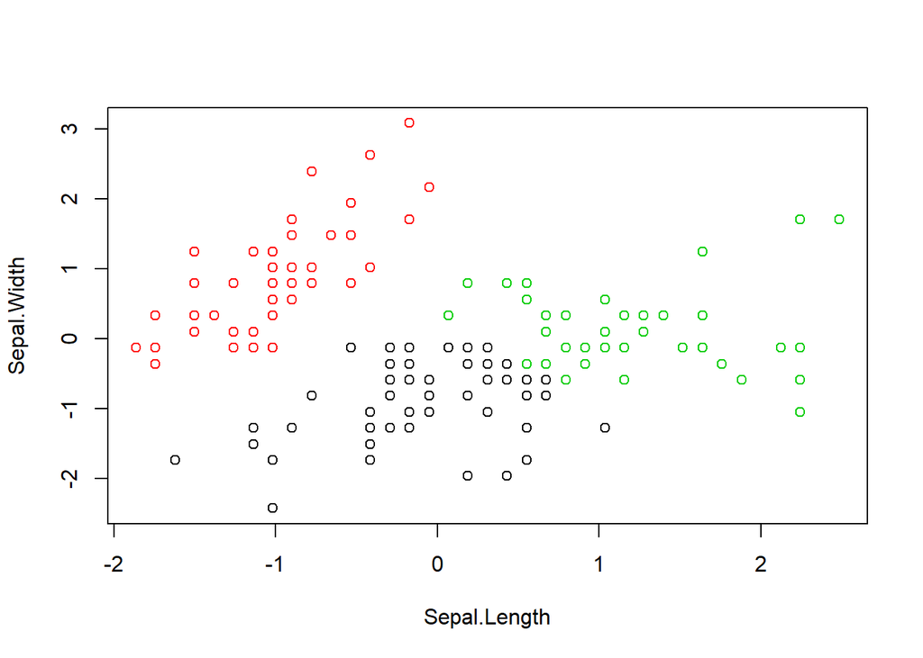

```r
plot(df, col = factor(k3$cluster))
```

## Task - plot the results for 2 clusters

Use 2 clusters and 5 starting positions.

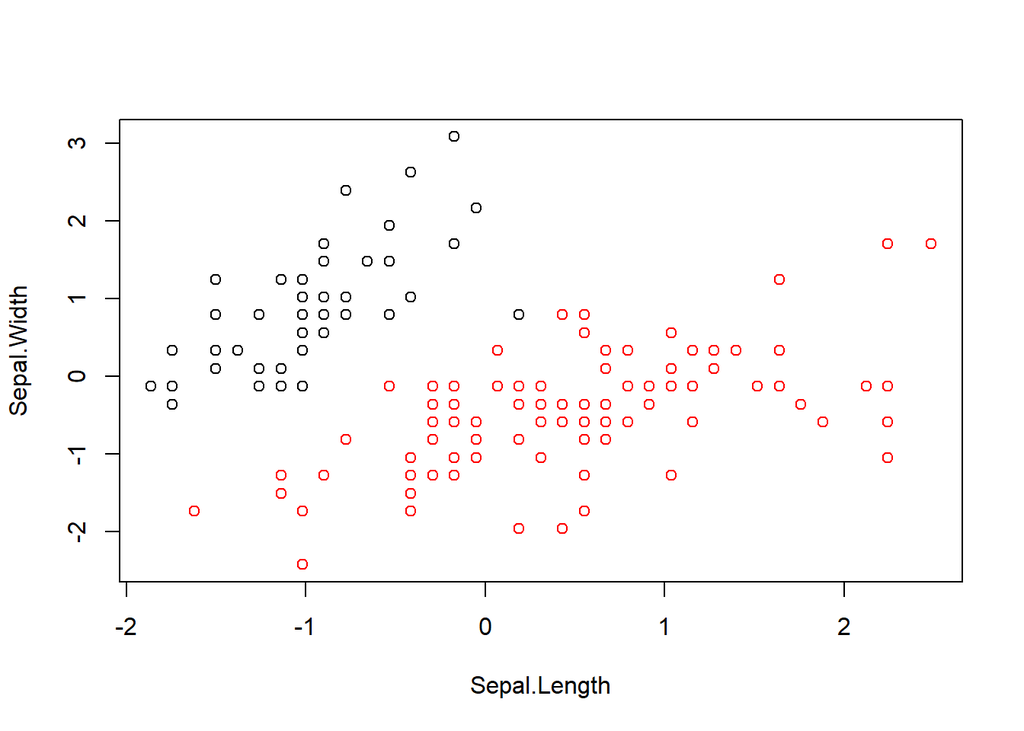

```r
plot(df, col = factor(k2$cluster))
```

## Visualisation using factoextra package

factoextra package contains a few useful functions for cluster analysis. One of them is fviz_cluster, which builds charts illustrating cluster membership of observations. The function requires specifying two arguments: kmeans output and original data frame.

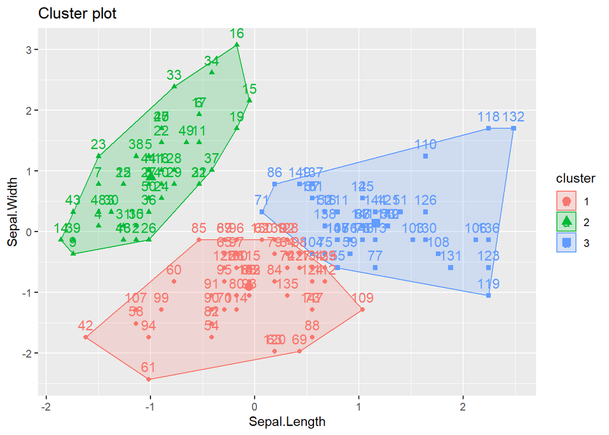

```r
# you might need to install factoextra package
# install.packages("factoextra")
library(factoextra)# load library
# plot clusters
fviz_cluster(k3, data = df)
```

# How to decide how many clusters to use?

Deciding how many clusters to use in k-means analysis can be a real challenge. There are numerous different methods and they often result in different cluster numbers - yikes! Let’s have a look at some of these.

## Elbow method

To use elbow method we need to compute Within cluster Sum of Squares (WSS). WSS is sum of squared distances between each point in a cluster and the center of the cluster. First we run analysis for different numbers of clusters and compute WSS for each k value.

```r
# initialise wss vector
wss = vector("numeric")
# compute wss for cluster number k = 1 to 10
for (k in 1:10) wss[k] = sum(kmeans(df, k, nstart = 5)$withinss)
```

Once we have the results we take a look at the plot of WSS against the number of clusters to find the “Elbow”. WSS value will decrease with the number of clusters k. Initally decrease in WSS will be large, but after k value reaches the elbow WSS does not decrease much and the line will be almost flat.

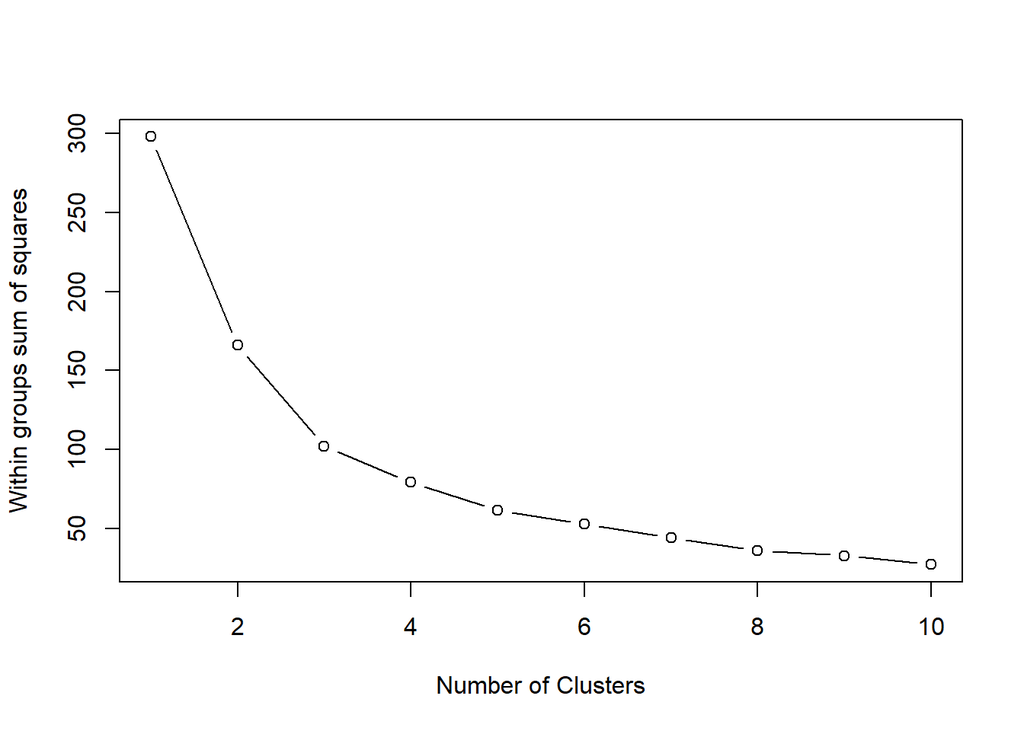

```r
#plot WSS against number of clusters
plot(1:10, wss, type="b", xlab="Number of Clusters",
     ylab="Within groups sum of squares")
```

## Silhouette method

Silhouette coefficient can take values from -1 to 1 and measures similarity within the cluster compared with other clusters. It is based on distance between an point and all the ohter points within the same/different clusters.

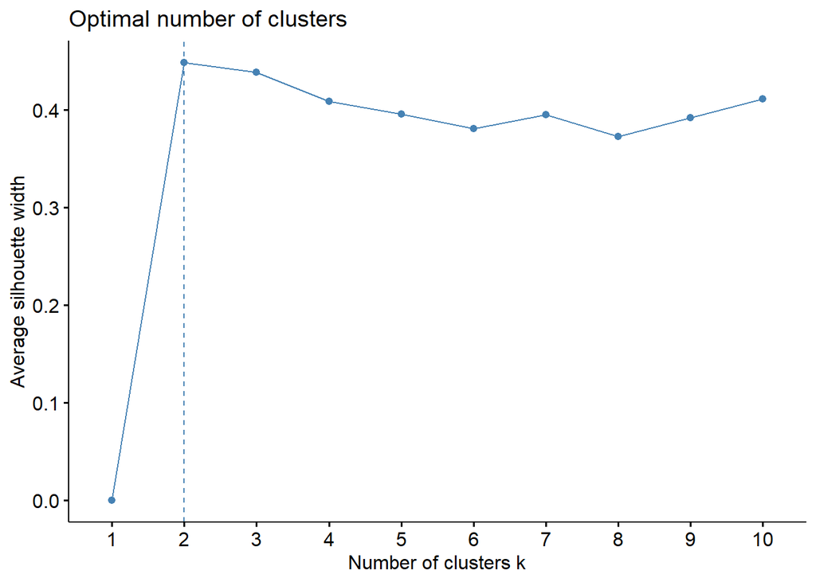

```r
fviz_nbclust(df, kmeans, method = "silhouette", k.max = 10, nstart = 5)
```

## Find optimal number of clusters using NbClust package

The NbClust package can compute 30 indices for determining the optimal number of clusters. If method ‘all’ is specified the function procudes all* indices and outlines how many of them suggest using given number of clusters.

We need to specify the dataset, minimum and maximum number of clusters we want to consider (2 to 10), clustering methods to use (kmeans) and indices to compute (all).

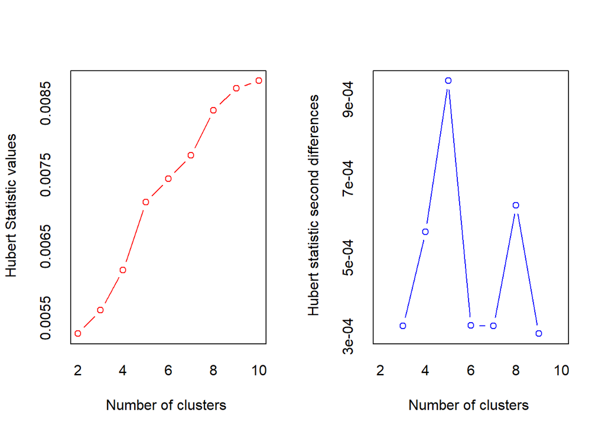

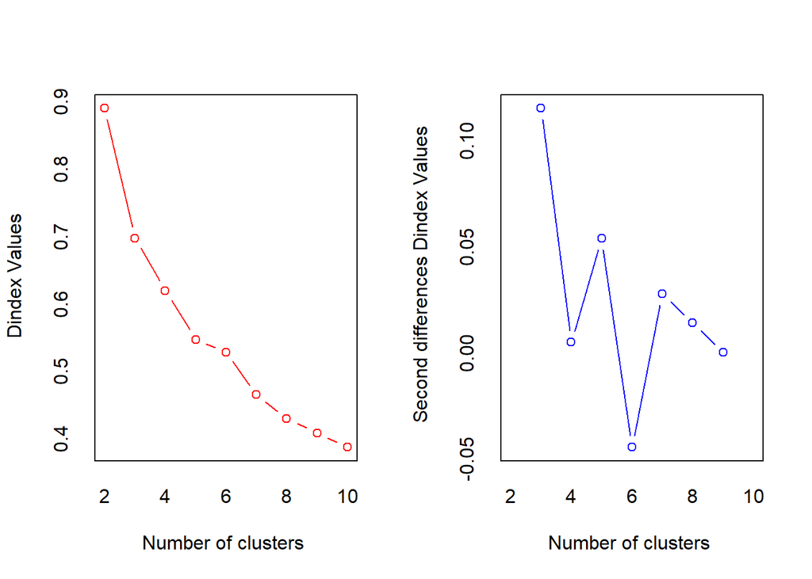

```r
# you might need to install NbClust package
# install.packages("NbClust")
library(NbClust)
res.nbclust = NbClust(df, min.nc = 2, max.nc = 10, method = "kmeans", index ="all")
```

We can use fvis_nbclust funtion fromm factoextra package to illustrate the result.

[output not shown]

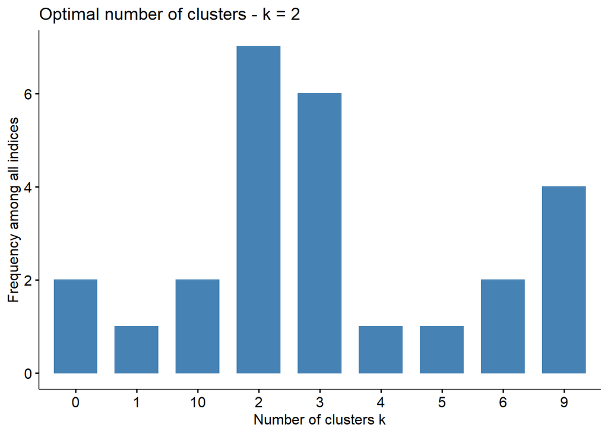

```r
fviz_nbclust(res.nbclust)
```

## Task - Identify the optimal number of clusters

Try identify the best number of clusters for the iris dataset when using all 4 variables.

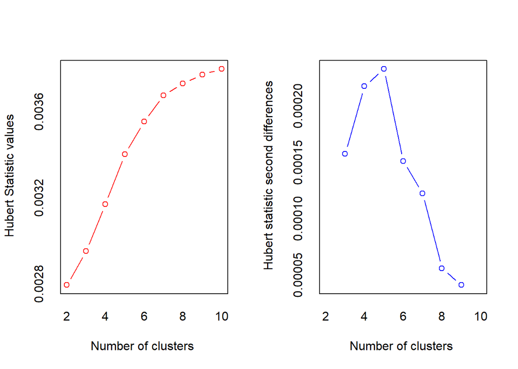

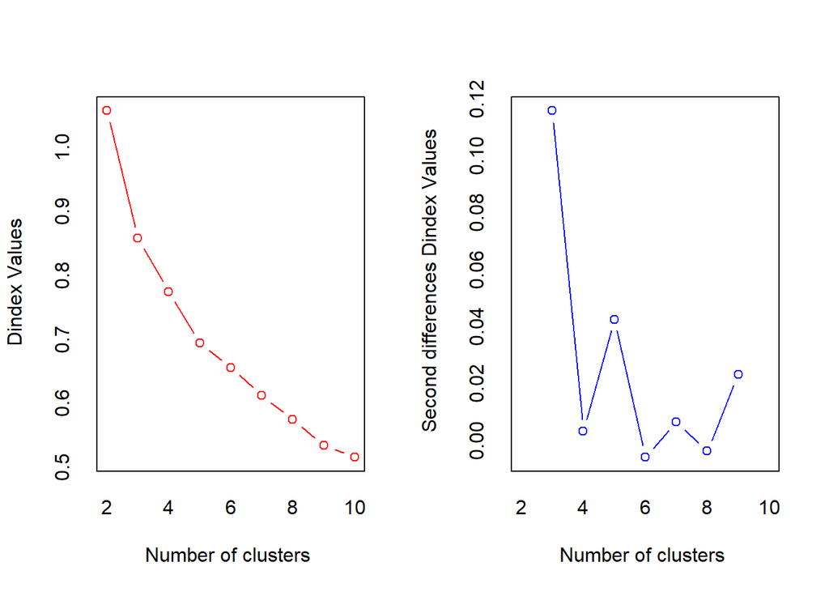

```r
# select columnns to use and normalize the data
df4 = scale(iris[1:4])
# find optimal number of clusters
res.nbclust = NbClust(df4, min.nc = 2, max.nc = 10, method = "kmeans", index ="all")
```

```
## Among all indices:
## ===================
## * 2 proposed  0 as the best number of clusters
## * 11 proposed  2 as the best number of clusters
## * 10 proposed  3 as the best number of clusters
## * 1 proposed  4 as the best number of clusters
## * 1 proposed  6 as the best number of clusters
## * 1 proposed  10 as the best number of clusters
##
## Conclusion
## =========================
## * According to the majority rule, the best number of clusters is  2 .
```

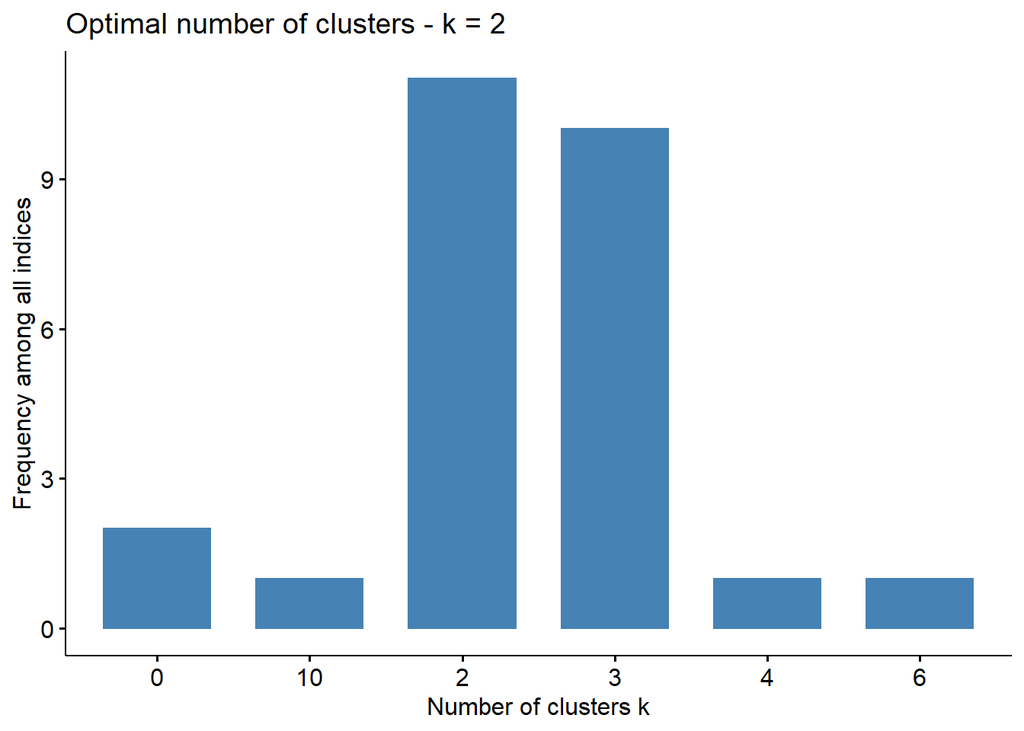

```r
fviz_nbclust(res.nbclust)
```

# Test your knowledge!

### [Take a quiz](https://forms.gle/JfvdFmgKoPhR8exv5)